**Name** : Mohit Ram Sharma  
**Roll Number**: 224161018  
**Assignment 1 of Data Visualization(CS596)**

```python
# Importing Libraries
try:
    import pandas as pd
    import numpy as np
    import matplotlib.pyplot as plt
    import matplotlib.patches as mpatches
    import seaborn as sns
except:
    !pip install numpy
    !pip install pandas
    !pip install matplotlib
    !pip install seaborn
    import pandas as pd
    import numpy as np
    import matplotlib.pyplot as plt
    import matplotlib.patches as mpatches
    import seaborn as sns
```

# Question 1

**Tabular data contains different types of variables. Some variables are categorical and some are numerical and continuous. Write a short note on the different types of variables. Include appropriate examples in your description**

## Types of variables

Variables are mainly of two types categorical(qualitative) and numeric(quantitative). Let's discuss them.

### Categorical Variables

- Categorical Variable are variables which only take a finite number of values.
- *These values need not have to be numbers.* For example, consider a database which contains all information of the students of IITG. Let **Programme** be the variable which tells us whether a student is in B.Tech, or M.Tech, or Ph.D or M.Sc, etc. The variable **Programme** is a categorical variable.
- *Categorical variables divide the data into several groups or categories.* For example, the data of students at IITG can be divided into several categories such as B.Tech students, M.Tech students, etc.
- Categorical variables can further be categorized as follows :
  - **Nominal**: These are variables that have two or more categories, but the categories do not have an intrinsic order between them.
    - *Example* : The **Programme** variable discussed above was a Nominal variable
  - **Binary/Dichotomous**: These variables are nominal variables which have only two categories.
    - *Example* : Let **sex** be the variable which tells us a particular student is Male or Female. Then sex is a binary variable.
  - **Oridnal**: These are variables that have two or more categories just like nominal variables but the categories here can be ordered or ranked.
    - *Example*: Suppose that in out student dataset we want to classify students base on their academics, where the categories are
      - Poor(less than 4 CGPA)
      - Below Average(4 to 6 CGPA)
      - Average(6 to 7.5 CGPA)
      - Above Average (7.5 to 8.5 CGPA)
      - Good(8.5 to 10 CGPA).

        Then the variable which will store this information will be a ordinal variable. Because here the categories can be ranked as *Poor < Below Average < Average < Above Average < Good.*

### Numeric Variables: These are variables whose values are numbers (except numbers which are codes standing up for categories).

- Numerical variables are mainly of two types, conitnuous variable and discrete variable which takes continuous and discrete values respectively.
- These variables are very important in statistics. In categorical variables, the categories describe the variables but in numerical variable, we can find average,median,standard deviation, etc. of and these quantities are used to describe the variable.
- Let's discuss type of numeric variables.
  - Discrete Variables :
    - A discrete variable is a numerical variable with a fintie/countable number of possible values.
    - *Example* : The number of courses a student takes in a semester is discrete variable. The student can take 4 or 5 or 6 or more number of courses. Number of courses for a student will always be a proper subset of the natural numbers, so the variable takes only finite values.
  - Continuous Variable :
    - A continuous variable is a variable which can take any value in a continuous/interval range.
    - *Example* : *Weight(in KG) of all students at IITG is a continous variable*. The weight of a student can be any positive real number between 0 to infinity(If we don't know beforehand what is the minimum and maximum weight, then the range of the variable is hard to predict).

# Question 2

**Tabular data are often presented in one of the following two formats: wide format, and long format. Write a short note differentiating the two formats. Your note should include appropriate examples. Further, using your choice of tool and language, show how you can convert one format into another.**

## Converting one format into another in pyhton :

```python
# A wide format tabular data
wide_data=pd.DataFrame({"Roll Number": ['224161018','224161019','224161020'],
                        "Programme": ['M.Tech','M.Tech','M.Tech'],
                       "First Name": ["Mohit",'Neel','Nikhil'],
                       "Last Name": ["Sharma",'Mani','Thoshar'],
                       "Year": ['First','First','First']})
wide_data
```

|  | Roll Number | Programme | First Name | Last Name | Year |
| --- | --- | --- | --- | --- | --- |
| 0 | 224161018 | M.Tech | Mohit | Sharma | First |
| 1 | 224161019 | M.Tech | Neel | Mani | First |
| 2 | 224161020 | M.Tech | Nikhil | Thoshar | First |

```python
wide_data.columns
```

```
Index(['Roll Number', 'Programme', 'First Name', 'Last Name', 'Year'], dtype='object')
```

### Wide to long format using pandas melt() funciton :

```python
# Converting to long format using melt function
long_data=wide_data.melt(id_vars='Roll Number',value_vars=['Programme', 'First Name', 'Last Name', 'Year'])
long_data
```

|  | Roll Number | variable | value |
| --- | --- | --- | --- |
| 0 | 224161018 | Programme | M.Tech |
| 1 | 224161019 | Programme | M.Tech |
| 2 | 224161020 | Programme | M.Tech |
| 3 | 224161018 | First Name | Mohit |
| 4 | 224161019 | First Name | Neel |
| 5 | 224161020 | First Name | Nikhil |
| 6 | 224161018 | Last Name | Sharma |
| 7 | 224161019 | Last Name | Mani |
| 8 | 224161020 | Last Name | Thoshar |
| 9 | 224161018 | Year | First |
| 10 | 224161019 | Year | First |
| 11 | 224161020 | Year | First |

### Long to wide fomrat using pandas pivot() function :

```python
# Converting long format to wide format using pivot function
wide_data=long_data.pivot(index='Roll Number',columns='variable',values='value')
wide_data
```

| variable Roll Number | First Name | Last Name | Programme | Year |
| --- | --- | --- | --- | --- |
| 224161018 | Mohit | Sharma | M.Tech | First |
| 224161019 | Neel | Mani | M.Tech | First |
| 224161020 | Nikhil | Thoshar | M.Tech | First |

# Question 3

**Variables in tabular data are either categorical or numerical. If you are using R, consider the heights data from the library dslabs. You can follow the steps given below to get access of data:**

- library(dslabs) //If it is not available, please install
- data("heights")

**If you are using Python or any other languages, then you may use the heights.csv file uploaded in the MS-Teams Files section. Answer the following questions.**

1. Which graph you will use to plot data for gender distribution and height distribution? Plot and Justify. Do we need any plot to understand gender distribution?
2. Show using a plot, what percentage of students have heights between 55 inches and 65 inches?
3. What range of heights contains 95% of the data? Which graph is effective to show such an analysis? Plot and give justification.

```python
heights=pd.read_csv("heights.csv")
```

```python
heights.head()
```

|  | Unnamed: 0 | sex | height |
| --- | --- | --- | --- |
| 0 | 1 | Male | 75.0 |
| 1 | 2 | Male | 70.0 |
| 2 | 3 | Male | 68.0 |
| 3 | 4 | Male | 74.0 |
| 4 | 5 | Male | 61.0 |

```python
heights.drop(['Unnamed: 0'],axis=1,inplace=True)
```

```python
heights.head(6)
```

|  | sex | height |
| --- | --- | --- |
| 0 | Male | 75.0 |
| 1 | Male | 70.0 |
| 2 | Male | 68.0 |
| 3 | Male | 74.0 |
| 4 | Male | 61.0 |
| 5 | Female | 65.0 |

## (I)

**Which graph you will use to plot data for gender distribution and height distribution? Plot and Justify. Do we need any plot to understand gender distribution?**

### Plot for gender distribution

The plot that suits the best to visualize the distribution of a categorical variable are **bar plot**. We use bar plot here. In bar plot, the categories are in one axis and in the other axis the frequencies of the categories are plotted as tall buildings(called bar), the higher the frequency of one category, the taller its building. By comparing the height of the buildings, we can easily interpret which categories are have high frequency.

Since here we have only two values for the categorical variable **'sex'**, so the number of bars are going to be two, which well enable us to understand the distribution quickly.

Another plot which can be used to visualize the distribution of a categorical variable is **pie chart** or **circle chart**. The frequency of a level of a categorical variable can be interpreted as a portion of the area of the circle.

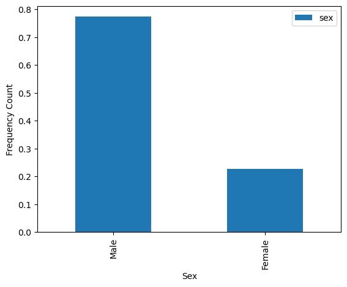

```python
sex_dist=heights['sex'].value_counts().to_frame()
sex_dist['sex']=sex_dist['sex']/heights.shape[0] # Normalizing the frequencies
sex_dist.plot(kind='bar')
plt.xlabel('Sex')
plt.ylabel('Frequency Count')
```

## Plot for height distribution

A **Histogram** is a good plot for visualizing the distribution of a continuous variable. In a histogram, we divide the x-axis into several intervals(called **bins**),then we count the number of values that fall in each bin and plot these values as bars on top of the intervals. This quicly tells us where majority of our data lies, what is the range of our data.

#### Plotting normalized frequency distribution of heights

```
<BarContainer object of 10 artists>
```

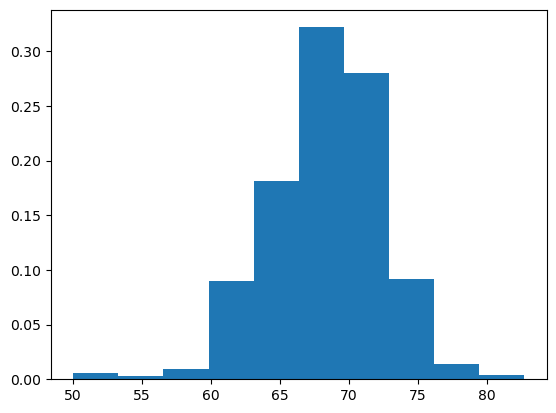

```python
heights_col=heights['height']
total_obs=len(heights_col)
# Calculating Normalized Frequency Distribution
min_h=heights_col.min()
max_h=heights_col.max()
n=10
b_s=(max_h-min_h)/n
H=np.zeros(n)
for i in range(total_obs):
  b_i=int(np.floor((heights_col[i]-min_h)/(b_s)))
  if b_i==n:
    b_i=b_i-1
  H[b_i]=H[b_i]+1/total_obs

bin_arr=[min_h+b_s*i for i in range(n+1)]
bin_arr=np.array(bin_arr)
plt.bar(bin_arr[:-1],H,width=b_s,align='edge')
```

### Do we need any plot to understand gender distribution ?

```python
sex_dist['sex']
```

```
Male      0.773333
Female    0.226667
Name: sex, dtype: float64
```

No, we do not need any plot to understand the gender distribution. As there are only two categories, male and female, so we have only two numbers describing the fequency. Any one number out of these two describes the distribution completely.

## (II) Show using a plot, what percentage of students have heights between 55 inches and 65 inches?

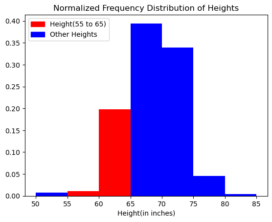

```python
bins=np.arange(50,90,5)
bins[3]=65
m=len(bins)-1
H1=np.zeros(m)
for i in range(total_obs):
    j=int(np.floor((heights_col[i]%50)/5))
    if heights_col[i]==65:
        j=2
    H1[j]=H1[j]+1/total_obs


colors=['b','r','r','b','b','b','b']
plt.bar(bins[:-1],H1,width=5,align='edge',color=colors)
plt.title('Normalized Frequency Distribution of Heights')
plt.xlabel('Height(in inches)')

# Adding Legend
red_patch = mpatches.Patch(color='red', label='Height(55 to 65)')
blue_patch = mpatches.Patch(color='blue', label='Other Heights')
plt.legend(handles=[red_patch, blue_patch],loc='upper left')
```

From the plot we see that nearly 20% students have heights between 55 inches and 65 inches.(The third bin(big red one) includes the frequency of 65. The fourth bin includes values in the interval (65,70]). Let's see the actual percentage of heights in between 55 and 65.

```python
(H1[1]+H1[2])*100
```

```
20.952380952380988
```

## (III) What range of heights contains 95% of the data? Which graph is effective to show such an analysis?

Histogram, which shows the normalized frequency distribution of the heights, is a good plot to see what range of height contains 95% of the data. We can quicky see which bins have very less frequency on top of it and the remaining bins are the bins where our majority of our data goes.

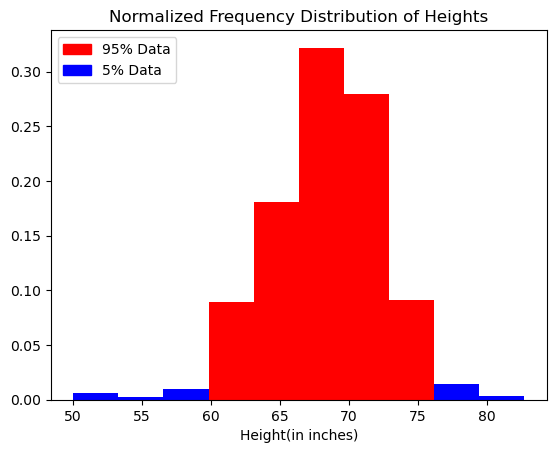

```python
colors=[]
sum=0
for i in range(len(H)):
    if H[i]<0.05 and sum<=0.05:
        colors.append('b')
    else:
        colors.append('r')
plt.bar(bin_arr[:-1],H,width=b_s,align='edge',color=colors)
plt.title('Normalized Frequency Distribution of Heights')
plt.xlabel('Height(in inches)')

# Adding Legend
red_patch = mpatches.Patch(color='red', label='95% Data')
blue_patch = mpatches.Patch(color='blue', label='5% Data')
plt.legend(handles=[red_patch, blue_patch],loc='upper left')
```

From the above figure we can see that about 95% of our data lies in the range 60 to 76. With increase in total number of bins, the endpoints of the range can be more precise.

# Question 4

**Use smoothed density curve to plot the height of Male students, highlighting the students with heights between 66 and 72 inches. For the same data, plot and justify how is smoothed density graph different from the histogram.**

Plotting the height of Male students using Smoohted density curve and highlighting the students with heights between 66 and 72 inches.

```python
male_height_data=heights.loc[heights['sex']=='Male',['height']]
```

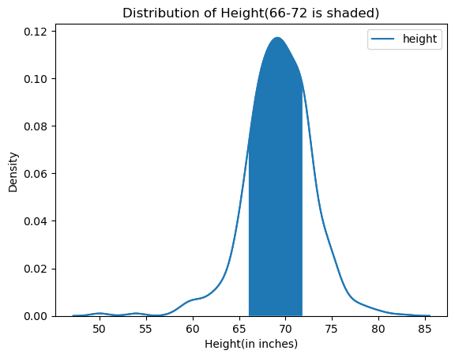

```python
sns.kdeplot(data=male_height_data)
ax=sns.kdeplot(data=male_height_data)

kde_lines = ax.get_lines()[-1]
kde_x, kde_y = kde_lines.get_data()

mask=(kde_x > 66) & (kde_x < 72)
filled_x, filled_y = kde_x[mask], kde_y[mask]

ax.fill_between(filled_x, filled_y)
ax.set_xlabel('Height(in inches)')
ax.set_title('Distribution of Height(66-72 is shaded)')
```

**For the same data, plot and justify how is smoothed density graph different from the histogram.**

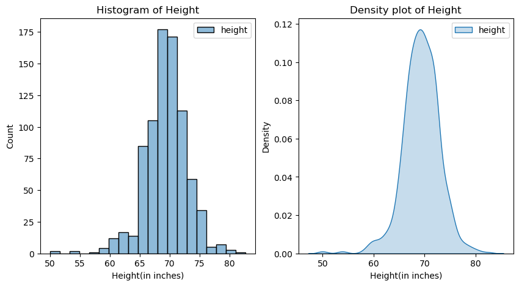

```python
fig,axes=plt.subplots(1,2,figsize=(10,5))
sns.histplot(ax=axes[0],data=male_height_data,bins=20)
axes[0].set_title("Histogram of Height")
axes[0].set_xlabel("Height(in inches)")

sns.kdeplot(ax=axes[1],data=male_height_data,fill=True)
axes[1].set_title("Density plot of Height")
axes[1].set_xlabel("Height(in inches)")
```

- The y-labels in density plot are changed from count to densities. Area under the curve for any interval gives an approximation to the proportion of heights in that interval.
- In histogram we can see few local peaks(in between 60 and 65, in between 76 to 80), and in the density plot these peaks are not there.
- Smooth density plot helps us to visualize the transition between heights smoothly(continuously), but in histogram the transition occurs in jumps/steps.

# Problem 5

**Does male height follow normal distribution? Justify your answer with suitable smoothed density plots. Also, answer what percentage of values lies within 1.5 standard deviations of the mean.**

```python
ht_mean=male_height_data.mean()[0] # mean height of Males
```

```python
ht_std=male_height_data.std()[0] # mean standard deviation of Males
```

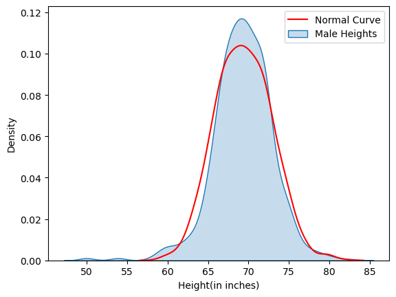

```python
normal_dist=np.random.normal(ht_mean,ht_std,1000)
sns.kdeplot(normal_dist,color='red')
sns.kdeplot(data=male_height_data,fill=True)
plt.legend(['Normal Curve','Male Heights'])
plt.xlabel("Height(in inches)")
plt.show()
```

**We can see that the male height data (almost) follows normal distribution.**

```python
count=0
ind=(male_height_data['height'] >= ht_mean-1.5*ht_std)&(male_height_data['height'] <= ht_mean+1.5*ht_std)
percent=(ind.sum()/len(male_height_data))*100
print(f'The percentage of values that lie within 1.5 standard deviations of the mean is {percent}')
```

```
The percentage of values that lie within 1.5 standard deviations of the mean is 88.79310344827587
```

# Problem 6

**If you are using R, upload the olive data from the dslabs library. You can do that by typing data("olive").**  
**If you are using Python or any other languages, then you may use the olive.csv file uploaded in the MS-Teams Files section.**  
**This data contains composition in the percentage of eight fatty acids found in the lipid fraction of 572 Italian olive oils.**  
**Your objective is to understand the correlation of palmitic acid with other acids. Choose the appropriate type of plot to show that.**

```python
olive=pd.read_csv("olive.csv")
olive.drop('Unnamed: 0',axis=1,inplace=True)
```

```python
olive.head()
```

|  | region | area | palmitic | palmitoleic | stearic | oleic | linoleic | linolenic | arachidic | eicosenoic |
| --- | --- | --- | --- | --- | --- | --- | --- | --- | --- | --- |
| 0 | Southern Italy | North-Apulia | 10.75 | 0.75 | 2.26 | 78.23 | 6.72 | 0.36 | 0.60 | 0.29 |
| 1 | Southern Italy | North-Apulia | 10.88 | 0.73 | 2.24 | 77.09 | 7.81 | 0.31 | 0.61 | 0.29 |
| 2 | Southern Italy | North-Apulia | 9.11 | 0.54 | 2.46 | 81.13 | 5.49 | 0.31 | 0.63 | 0.29 |
| 3 | Southern Italy | North-Apulia | 9.66 | 0.57 | 2.40 | 79.52 | 6.19 | 0.50 | 0.78 | 0.35 |
| 4 | Southern Italy | North-Apulia | 10.51 | 0.67 | 2.59 | 77.71 | 6.72 | 0.50 | 0.80 | 0.46 |

## Which plot will we use to understand the correlation of palmitic acid with other acids?

To understand the correlation between two continuous variables, scatterplot is the best choice. If X and Y are two continuous variables, then scatterplot plots different values that X and Y take on the plane.

If there is some relationship between X and Y the scatterplot will probably capture the relationship by showing us some patterns in the plot.

Let's plot the scatterplot of palmitic acid with few other acids

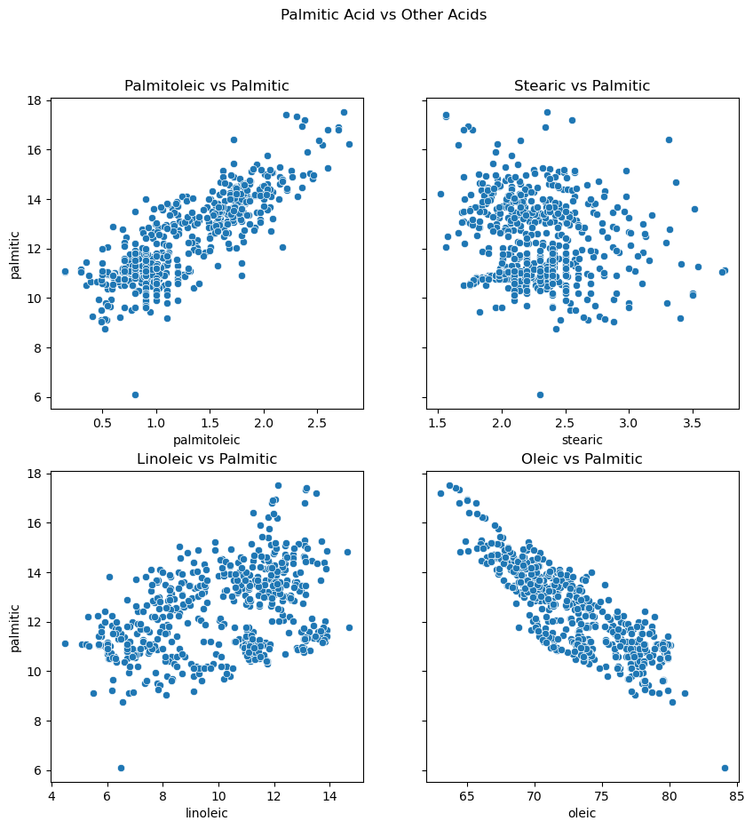

```python
fig,axes=plt.subplots(2,2,figsize=(10,10),sharey=True)
sns.scatterplot(ax=axes[0,0],x=olive.palmitoleic,y=olive.palmitic)
axes[0,0].set_title("Palmitoleic vs Palmitic")

sns.scatterplot(ax=axes[0,1],data=olive,x='stearic',y='palmitic')
axes[0,1].set_title('Stearic vs Palmitic')

sns.scatterplot(ax=axes[1,0],data=olive,x='linoleic',y='palmitic')
axes[1,0].set_title('Linoleic vs Palmitic')

sns.scatterplot(ax=axes[1,1],data=olive,x='oleic',y='palmitic')
axes[1,1].set_title('Oleic vs Palmitic')

fig.suptitle("Palmitic Acid vs Other Acids")
```

By seeing the above plot, one can quickly understand the correlation of palmitic acids with palmitoleic, stearic, linoleic, and oleic.

- Palmitic and Palmitoleic acids are positively correlated.
- Palmitic and Stearica acids are negatively correlated.
- Palmitic and Linoleic acids are positively correlated.
- Palmitic and Oleic acids are negatively correlated.

We can get more insights on the correlation using scatterplots. For example, Does **'region'** plays any role in the correlation of palmitic acid with other acids varies from region to region ? Let's see this

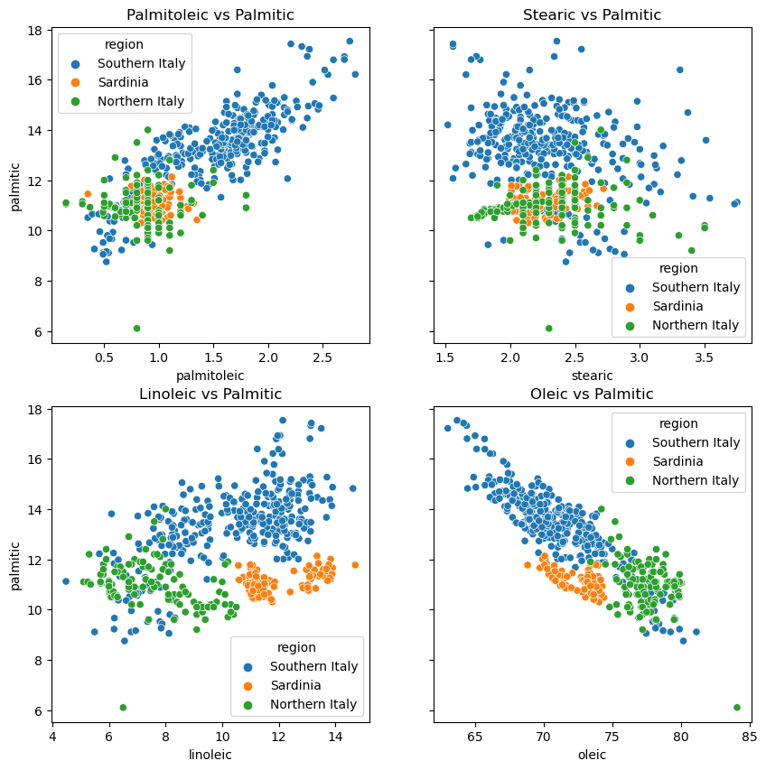

```python
fig,axes=plt.subplots(2,2,figsize=(10,10),sharey=True)
sns.scatterplot(ax=axes[0,0],x=olive.palmitoleic,y=olive.palmitic,hue=olive.region)
axes[0,0].set_title("Palmitoleic vs Palmitic")

sns.scatterplot(ax=axes[0,1],data=olive,x='stearic',y='palmitic',hue=olive.region)
axes[0,1].set_title('Stearic vs Palmitic')

sns.scatterplot(ax=axes[1,0],data=olive,x='linoleic',y='palmitic',hue=olive.region)
axes[1,0].set_title('Linoleic vs Palmitic')

sns.scatterplot(ax=axes[1,1],data=olive,x='oleic',y='palmitic',hue=olive.region)
axes[1,1].set_title('Oleic vs Palmitic')
```

Surely we have more insights now as compared to before.

- **Palmitic vs Palmitoleic**:
  - There is almost **no correlation** between the two acids in **Sardinia** and **Northern Italy** regions.
  - Only in the **Southern Italy** region the two variables are **positively correlated**.
- **Palmitic vs Stearic**:
  - Again there is almost **no correlation** between the two acids in **Sardinia** and **Northern Italy** regions.
  - The acids are **negatively correlated** in the **Southern Italy** region.
- **Palmitic vs Linoleic**:
  - There is **positive correlation** between the two acids in the **Southern Italy** region.
  - There is **weak negative correlation** between the two acids in the **Northern Italy** region.
  - There is **no correlation** between the two acids in the **Sardinia** region
- **Palmitic vs Oleic**:
  - There is negative correlation in all the regions.

Let's see the correlation of Palmitic acids with Linolenic and Arachidic acids.

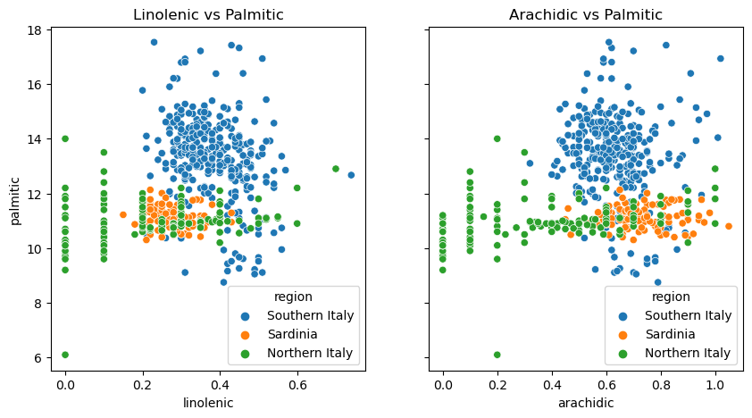

```python
fig,axes=plt.subplots(1,2,figsize=(10,5),sharey=True)
sns.scatterplot(ax=axes[0],x=olive.linolenic,y=olive.palmitic,hue=olive.region)
axes[0].set_title("Linolenic vs Palmitic")

sns.scatterplot(ax=axes[1],data=olive,x='arachidic',y='palmitic',hue=olive.region)
axes[1].set_title('Arachidic vs Palmitic')
```

We can see that in the **Sardinia** region there is almost no corrlation of palmitic acid with linolenic and arachidic acids.

It seems like that there is a slightly **negative** and **positive correlation** of palmitic acid with linolenic and arachidic acid in the **Southern Italy** and **Northern Italy** region, respectavily.

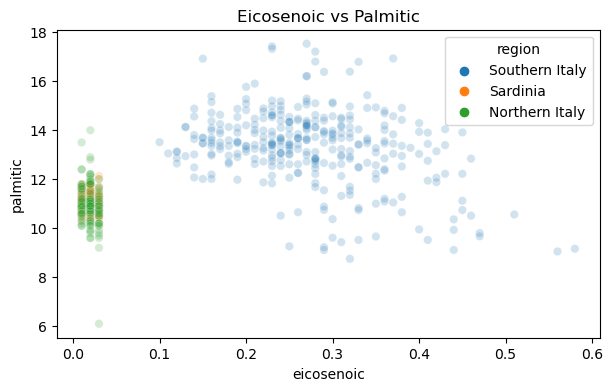

```python
plt.figure(figsize=(7,4))
sns.scatterplot(data=olive,x='eicosenoic',y='palmitic',hue='region',alpha=0.2)
plt.title('Eicosenoic vs Palmitic')
plt.show()
```

The Eicoenoic acid has values only in the range {0.01, 0.02, 0.03} in the Sardinia and Northern Italy. As this is a discrete set, so the concept of correlation is not suitable in this case.

Also no immediate observation can be made regarding the correlation of Palmitic acid with Eicosenoic acid in Northern italy.

```python
# We can test our intuitions about the observations by running the following codes, if necessary.
# olive.iloc[:,2:9].corr()
# olive[olive['region']=="Northern Italy"].iloc[:,2:9].corr()
# olive[olive['region']=="Soutthern Italy"].iloc[:,2:9].corr()
# olive[olive['region']=="Sardinia"].iloc[:,2:9].corr()
```